# R Notebook

| Title: “IST707 HW4 Use Clustering to Solve a Mystery in History” |
| --- |
| Name: Sathish Kumar Rajendiran |
| Date: 07/30/2020 |

Exercise: Use clustering methods to solve a mystery in history: who wrote the disputed essays, Hamilton or Madison?

In this homework you are provided with the Federalist Paper data set. The features are a set of “function words”, for example, “upon”. The feature value is the percentage of the word occurrence in an essay. For example, for the essay “Hamilton_fed_31.txt”, if the function word “upon” appeared 3 times, and the total number of words in this essay is 1000, the feature value is 3/1000=0.3% Now you are going to try solving this mystery using clustering algorithms k-Means, EM, and HAC. Document your analysis process and draw your conclusion on who wrote the disputed essays. Provide evidence for each method to demonstrate what patterns had been learned to predict the disputed papers, for example, visualize the clustering results and show where the disputed papers are located in relation to Hamilton and Madison’s papers. By the way, where are the papers with joint authorship located? For k-Means and EM, analyze the centroids to explain which attributes are most useful for clustering. Hint: the centroid values on these dimensions should be far apart from each other to be able to distinguish the clusters.

```r
# import libraries
#create a function to ensure the libraries are imported
EnsurePackage <- function(x){
  x <- as.character(x)
    if (!require(x,character.only = TRUE)){
      install.packages(pkgs=x, repos = "http://cran.us.r-project.org")
      require(x, character.only = TRUE)
    }
  }
# usage example, to load the necessary library for further processing...
EnsurePackage("dplyr")
EnsurePackage("ggplot2")
EnsurePackage("sqldf")
EnsurePackage("reshape2")
EnsurePackage("wordcloud")
EnsurePackage("RColorBrewer")
EnsurePackage("tidyverse")
EnsurePackage("tidytext")
EnsurePackage("factoextra")
EnsurePackage("NbClust")
cat("All Packages are available")
```

```
All Packages are available
```

```r
#Load CSV into data frame
  filepath <- "/Users/sathishrajendiran/Documents/R/fedPapers85.csv"
  fedPapersDF <- data.frame(read.csv(filepath,na.strings=c(""," ","NA")),stringsAsFactors=FALSE)
  dim(fedPapersDF) #85 72
```

```
[1] 85 72
```

```r
# Analyze the spread
  summary(fedPapersDF)
```

```
      author               filename        a               all               also                an               and              any               are                as               at                be
 dispt   :11   dispt_fed_49.txt: 1   Min.   :0.0960   Min.   :0.01500   Min.   :0.000000   Min.   :0.00900   Min.   :0.2170   Min.   :0.00000   Min.   :0.01300   Min.   :0.0270   Min.   :0.00000   Min.   :0.0400
 Hamilton:51   dispt_fed_50.txt: 1   1st Qu.:0.2400   1st Qu.:0.03500   1st Qu.:0.000000   1st Qu.:0.04900   1st Qu.:0.3190   1st Qu.:0.02500   1st Qu.:0.05100   1st Qu.:0.1000   1st Qu.:0.02600   1st Qu.:0.2580
 HM      : 3   dispt_fed_51.txt: 1   Median :0.2990   Median :0.05000   Median :0.007000   Median :0.07100   Median :0.3580   Median :0.04300   Median :0.06800   Median :0.1240   Median :0.03800   Median :0.3070
 Jay     : 5   dispt_fed_52.txt: 1   Mean   :0.2932   Mean   :0.05284   Mean   :0.007659   Mean   :0.06839   Mean   :0.3846   Mean   :0.04161   Mean   :0.07707   Mean   :0.1242   Mean   :0.04427   Mean   :0.3012
 Madison :15   dispt_fed_53.txt: 1   3rd Qu.:0.3490   3rd Qu.:0.06600   3rd Qu.:0.013000   3rd Qu.:0.08500   3rd Qu.:0.4130   3rd Qu.:0.05600   3rd Qu.:0.10200   3rd Qu.:0.1440   3rd Qu.:0.06300   3rd Qu.:0.3580
               dispt_fed_54.txt: 1   Max.   :0.4660   Max.   :0.12700   Max.   :0.047000   Max.   :0.17900   Max.   :0.8210   Max.   :0.11400   Max.   :0.16300   Max.   :0.2520   Max.   :0.11800   Max.   :0.4810
               (Other)         :79
      been              but                by              can                do                down               even            every              for.              from              had               has
 Min.   :0.00000   Min.   :0.00000   Min.   :0.0270   Min.   :0.00000   Min.   :0.000000   Min.   :0.000000   Min.   :0.0000   Min.   :0.00000   Min.   :0.03000   Min.   :0.02600   Min.   :0.00000   Min.   :0.00000
 1st Qu.:0.03000   1st Qu.:0.02200   1st Qu.:0.0920   1st Qu.:0.01400   1st Qu.:0.000000   1st Qu.:0.000000   1st Qu.:0.0000   1st Qu.:0.00900   1st Qu.:0.07000   1st Qu.:0.05700   1st Qu.:0.00800   1st Qu.:0.02500
 Median :0.05300   Median :0.03200   Median :0.1240   Median :0.02900   Median :0.006000   Median :0.000000   Median :0.0100   Median :0.02200   Median :0.08800   Median :0.07800   Median :0.01600   Median :0.04600
 Mean   :0.05967   Mean   :0.03232   Mean   :0.1272   Mean   :0.03558   Mean   :0.006259   Mean   :0.001529   Mean   :0.0114   Mean   :0.02391   Mean   :0.09376   Mean   :0.07978   Mean   :0.02116   Mean   :0.04442
 3rd Qu.:0.08400   3rd Qu.:0.04200   3rd Qu.:0.1620   3rd Qu.:0.05200   3rd Qu.:0.010000   3rd Qu.:0.000000   3rd Qu.:0.0180   3rd Qu.:0.03400   3rd Qu.:0.11400   3rd Qu.:0.09800   3rd Qu.:0.02700   3rd Qu.:0.05700
 Max.   :0.16500   Max.   :0.08900   Max.   :0.2640   Max.   :0.11000   Max.   :0.028000   Max.   :0.017000   Max.   :0.0370   Max.   :0.08700   Max.   :0.21300   Max.   :0.16200   Max.   :0.14100   Max.   :0.11400

      have              her                his               if.               in.              into               is               it              its               may               more              must
 Min.   :0.01100   Min.   :0.000000   Min.   :0.00000   Min.   :0.00000   Min.   :0.1890   Min.   :0.00000   Min.   :0.0280   Min.   :0.0750   Min.   :0.00000   Min.   :0.00000   Min.   :0.00000   Min.   :0.00000
 1st Qu.:0.07300   1st Qu.:0.000000   1st Qu.:0.00000   1st Qu.:0.01600   1st Qu.:0.2670   1st Qu.:0.01000   1st Qu.:0.1180   1st Qu.:0.1290   1st Qu.:0.03000   1st Qu.:0.03600   1st Qu.:0.02300   1st Qu.:0.01400
 Median :0.09000   Median :0.000000   Median :0.01400   Median :0.02600   Median :0.3040   Median :0.02200   Median :0.1510   Median :0.1510   Median :0.04200   Median :0.05600   Median :0.04400   Median :0.02700
 Mean   :0.09474   Mean   :0.008094   Mean   :0.02862   Mean   :0.02733   Mean   :0.3174   Mean   :0.02409   Mean   :0.1563   Mean   :0.1567   Mean   :0.04836   Mean   :0.06181   Mean   :0.04561   Mean   :0.03305
 3rd Qu.:0.12400   3rd Qu.:0.007000   3rd Qu.:0.03900   3rd Qu.:0.03400   3rd Qu.:0.3550   3rd Qu.:0.03400   3rd Qu.:0.1960   3rd Qu.:0.1900   3rd Qu.:0.06400   3rd Qu.:0.08500   3rd Qu.:0.06100   3rd Qu.:0.04400
 Max.   :0.18500   Max.   :0.150000   Max.   :0.24700   Max.   :0.09900   Max.   :0.4990   Max.   :0.10500   Max.   :0.3230   Max.   :0.2840   Max.   :0.15000   Max.   :0.13400   Max.   :0.13000   Max.   :0.11100

       my                 no               not               now                 of               on               one               only               or               our            shall             should
 Min.   :0.000000   Min.   :0.00000   Min.   :0.02000   Min.   :0.000000   Min.   :0.5620   Min.   :0.00000   Min.   :0.00500   Min.   :0.00000   Min.   :0.02700   Min.   :0.000   Min.   :0.00000   Min.   :0.00000
 1st Qu.:0.000000   1st Qu.:0.02000   1st Qu.:0.07500   1st Qu.:0.000000   1st Qu.:0.8560   1st Qu.:0.04300   1st Qu.:0.02700   1st Qu.:0.01000   1st Qu.:0.07000   1st Qu.:0.000   1st Qu.:0.00600   1st Qu.:0.01000
 Median :0.000000   Median :0.02900   Median :0.09500   Median :0.005000   Median :0.9020   Median :0.06200   Median :0.03600   Median :0.02200   Median :0.08100   Median :0.013   Median :0.01400   Median :0.02700
 Mean   :0.003259   Mean   :0.03236   Mean   :0.09248   Mean   :0.006035   Mean   :0.9094   Mean   :0.06926   Mean   :0.04079   Mean   :0.02288   Mean   :0.09674   Mean   :0.023   Mean   :0.01875   Mean   :0.02656
 3rd Qu.:0.005000   3rd Qu.:0.04300   3rd Qu.:0.11200   3rd Qu.:0.010000   3rd Qu.:0.9690   3rd Qu.:0.09700   3rd Qu.:0.05000   3rd Qu.:0.03400   3rd Qu.:0.11600   3rd Qu.:0.028   3rd Qu.:0.02700   3rd Qu.:0.03800
 Max.   :0.056000   Max.   :0.08300   Max.   :0.14800   Max.   :0.026000   Max.   :1.2110   Max.   :0.15600   Max.   :0.13500   Max.   :0.06500   Max.   :0.32100   Max.   :0.199   Max.   :0.07900   Max.   :0.09100
```

[output cut: 16 more lines]

| author | variable | value |
| --- | --- | --- |
| dispt | a | 0.280 |
| dispt | a | 0.177 |
| dispt | a | 0.339 |
| dispt | a | 0.270 |
| dispt | a | 0.303 |
| dispt | a | 0.245 |
| dispt | a | 0.349 |
| dispt | a | 0.414 |
| dispt | a | 0.248 |
| dispt | a | 0.442 |

[output cut: 990 more lines]

```r
# Build Word Cloud on dispt_df's
dispt_df
```

|  | word | freq |
| --- | --- | --- |
| 256 | the | 14.377 |
| 191 | of | 9.737 |
| 286 | to | 4.979 |
| 46 | be | 3.951 |
| 21 | and | 3.916 |
| 1 | a | 3.343 |
| 131 | in. | 3.036 |
| 251 | that | 2.198 |
| 321 | which | 1.862 |
| 141 | is | 1.802 |

[output cut: 60 more lines]

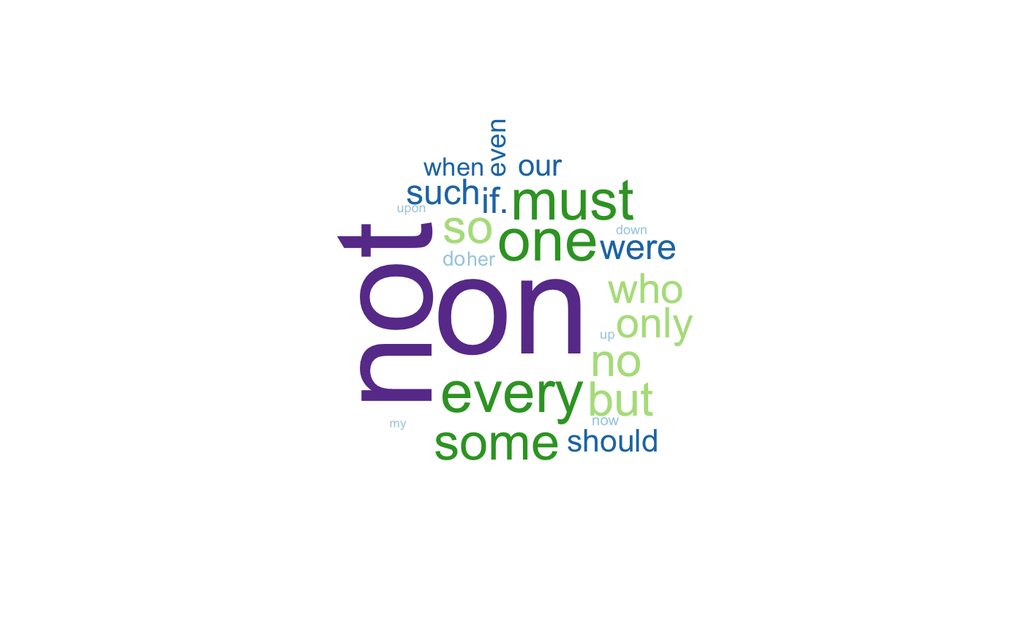

```r
dispt_df <- dispt_df[!grepl('the|to|and|of|which|in.|by|be|that|it|a|is|as|will|would|for|from|or',dispt_df$word),] #remove common words across all articles
wordcloud(dispt_df$word,dispt_df$freq,rot.per = .15,random.order = FALSE,colors = brewer.pal(10,"Paired"),scale=c(6,.5))
```

```r
# Build Word Cloud on Hamilton_df's
Hamilton_df
```

|  | word | freq |
| --- | --- | --- |
| 257 | the | 65.787 |
| 192 | of | 48.816 |
| 287 | to | 30.145 |
| 132 | in. | 17.539 |
| 22 | and | 17.314 |
| 2 | a | 16.096 |
| 47 | be | 15.727 |
| 252 | that | 11.280 |
| 322 | which | 8.185 |
| 142 | is | 8.130 |

[output cut: 60 more lines]

[figure not shown]

```r
Hamilton_df <- Hamilton_df[!grepl('the|to|and|of|which|in.|by|be|that|it|a|is|as|will|would|for|from|or',Hamilton_df$word),] #remove common words across all articles
wordcloud(Hamilton_df$word,Hamilton_df$freq,rot.per = .15,random.order = FALSE,colors = brewer.pal(10,"Paired"),scale=c(6,.5))
```

```r
# Build Word Cloud on Madison's
Madison_df
```

|  | word | freq |
| --- | --- | --- |
| 260 | the | 20.629 |
| 195 | of | 13.031 |
| 290 | to | 6.853 |
| 25 | and | 6.295 |
| 50 | be | 4.343 |
| 135 | in. | 4.296 |
| 5 | a | 4.047 |
| 255 | that | 3.023 |
| 145 | is | 2.571 |
| 65 | by | 2.491 |

[output cut: 60 more lines]

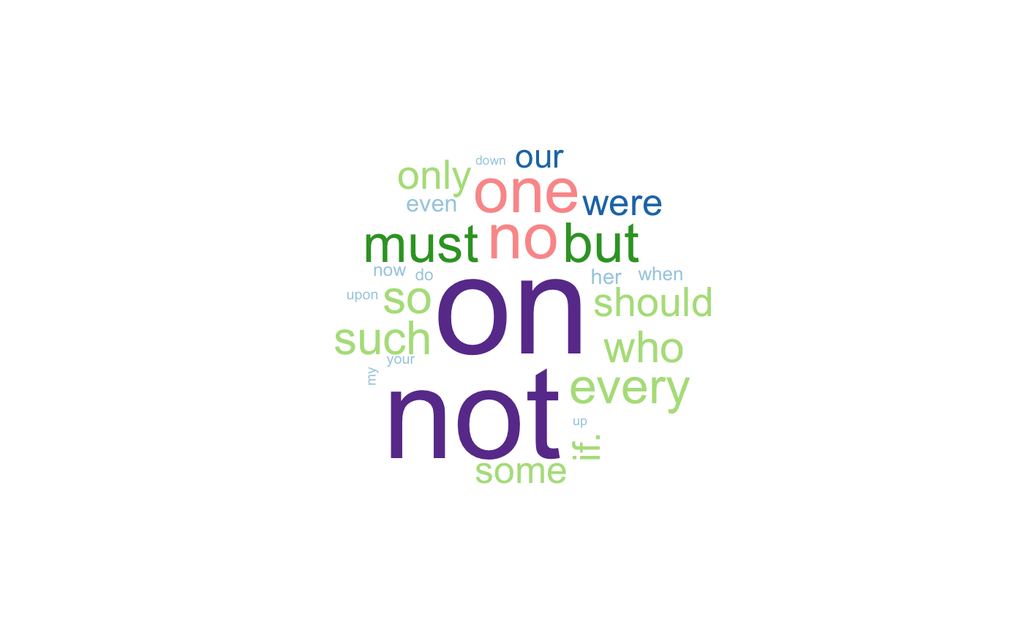

```r
Madison_df <- Madison_df[!grepl('the|to|and|of|which|in.|by|be|that|it|a|is|as|will|would|for|from|or',Madison_df$word),] #remove common words across all articles
wordcloud(Madison_df$word,Madison_df$freq,rot.per = .15,random.order = FALSE,colors = brewer.pal(10,"Paired"),scale=c(6,.5))
```

```r
# Build Word Cloud on HM's
HM_df
```

|  | word | freq |
| --- | --- | --- |
| 258 | the | 3.801 |
| 193 | of | 2.516 |
| 23 | and | 1.592 |
| 288 | to | 1.148 |
| 133 | in. | 0.747 |
| 3 | a | 0.640 |
| 63 | by | 0.525 |
| 323 | which | 0.412 |
| 263 | their | 0.397 |
| 303 | was | 0.342 |

[output cut: 60 more lines]

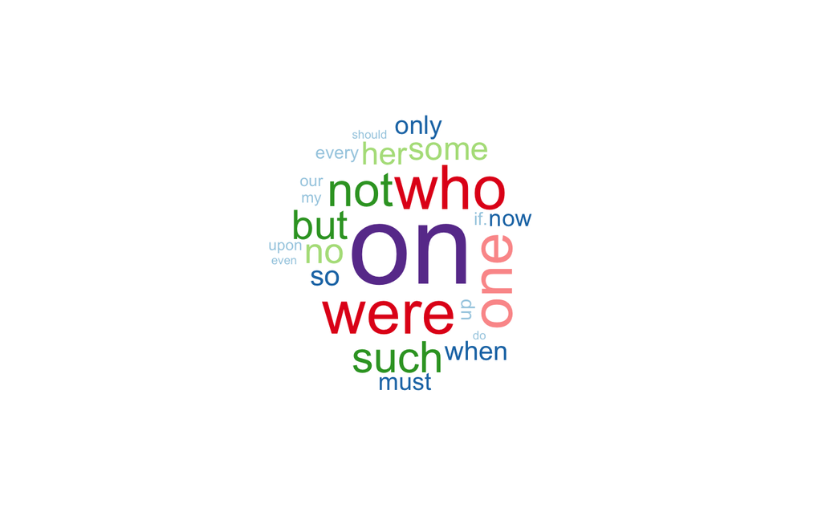

```r
HM_df <- HM_df[!grepl('the|to|and|of|which|in.|by|be|that|it|a|is|as|will|would|for|from|or',HM_df$word),] #remove common words across all articles
wordcloud(HM_df$word,HM_df$freq,rot.per = .15,random.order = FALSE,colors = brewer.pal(10,"Paired"),scale=c(6,.5))
```

```r
# Build Word Cloud on Jay's
Jay_df
```

|  | word | freq |
| --- | --- | --- |
| 259 | the | 4.272 |
| 24 | and | 3.576 |
| 194 | of | 3.195 |
| 289 | to | 2.417 |
| 49 | be | 1.377 |
| 134 | in. | 1.357 |
| 254 | that | 1.217 |
| 149 | it | 1.024 |
| 214 | or | 0.804 |
| 4 | a | 0.799 |

[output cut: 60 more lines]

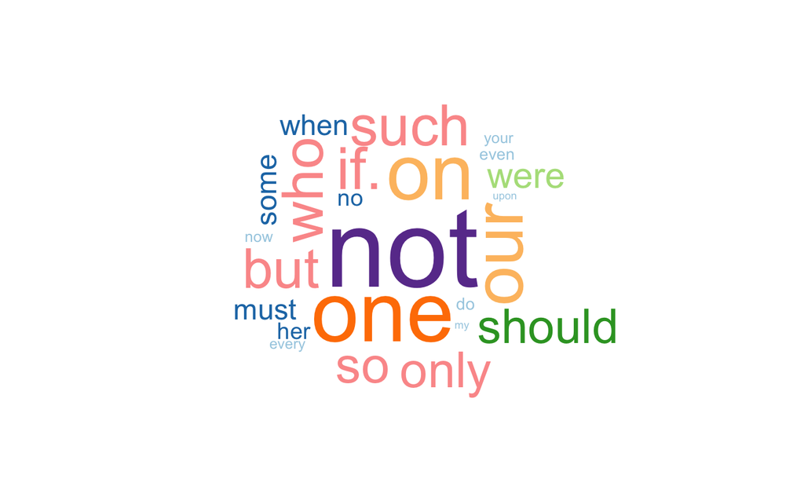

```r
Jay_df <- Jay_df[!grepl('the|to|and|of|which|in.|by|be|that|it|a|is|as|will|would|for|from|or',Jay_df$word),] #remove common words across all articles
wordcloud(Jay_df$word,Jay_df$freq,rot.per = .15,random.order = FALSE,colors = brewer.pal(10,"Paired"),scale=c(6,.5))
```

```r
    clnames #0
```

```
character(0)
```

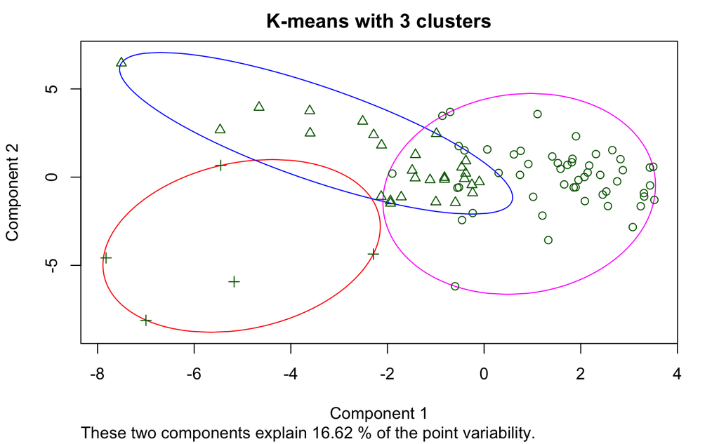

|  | author | cluster | n |
| --- | --- | --- | --- |
| 7 | dispt | 1 | 2 |
| 8 | dispt | 2 | 9 |
| 2 | Hamilton | 1 | 49 |
| 3 | Hamilton | 2 | 2 |
| 1 | HM | 2 | 3 |
| 4 | Jay | 3 | 5 |
| 5 | Madison | 1 | 1 |
| 6 | Madison | 2 | 14 |

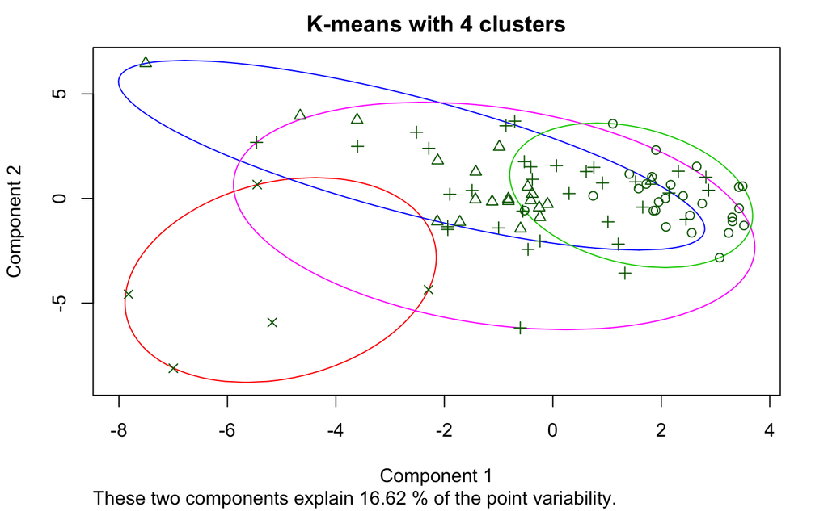

|  | author | cluster | n |
| --- | --- | --- | --- |
| 9 | dispt | 2 | 7 |
| 10 | dispt | 3 | 4 |
| 3 | Hamilton | 1 | 27 |
| 4 | Hamilton | 2 | 2 |
| 5 | Hamilton | 3 | 22 |
| 1 | HM | 2 | 2 |
| 2 | HM | 3 | 1 |
| 6 | Jay | 4 | 5 |
| 7 | Madison | 2 | 9 |
| 8 | Madison | 3 | 6 |

[figure not shown]

[output not shown]

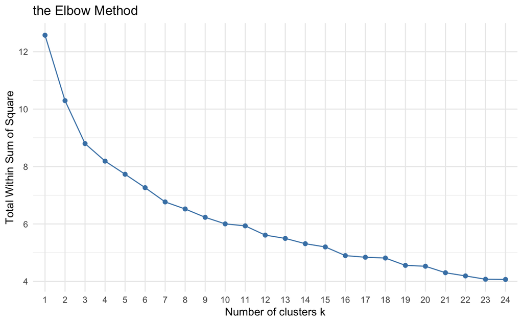

```r
# fviz_nbclust(MfedPapersDF, kmeans, method = c("silhouette", "wss", "gap_stat"))

set.seed(123)
# function to compute total within-cluster sum of squares
factoextra::fviz_nbclust(MfedPapersDF, kmeans, method = "wss", k.max = 24) + theme_minimal() + ggtitle("the Elbow Method")
```

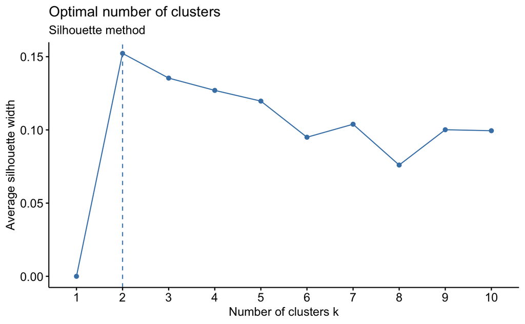

```r
set.seed(123)
# Silhouette method
factoextra::fviz_nbclust(MfedPapersDF, kmeans, method = "silhouette")+ labs(subtitle = "Silhouette method")
```

```
Clustering k = 1,2,..., K.max (= 10): .. done
Bootstrapping, b = 1,2,..., B (= 50)  [one "." per sample]:
.................................................. 50
```

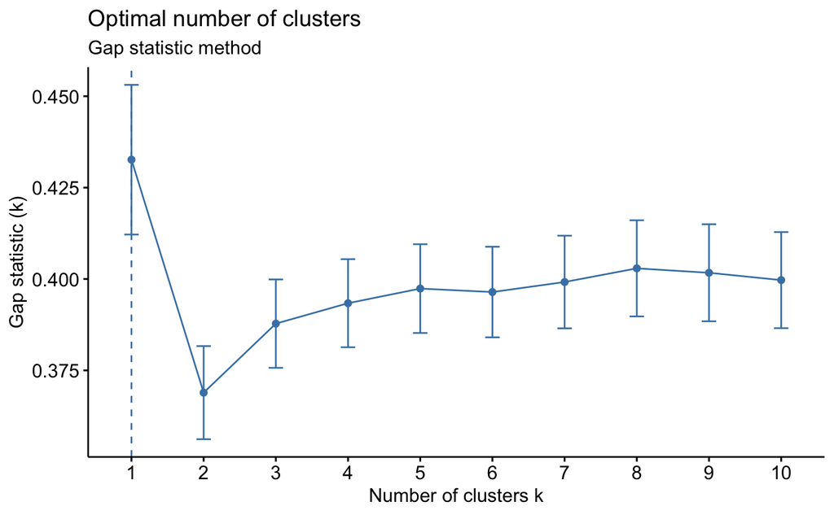

```r
set.seed(123)
# Gap statistic
factoextra::fviz_nbclust(MfedPapersDF, kmeans, nstart = 25,  method = "gap_stat", nboot = 50)+ labs(subtitle = "Gap statistic method")
```